[figure not shown]

# Методы машинного обучения

### Шестаков Андрей (avshestakov@hse.ru)

## Методы кластеризации

## Цели и задача кластеризации

### Задача

Основная задача кластерного анализа — разбиение исходного набора объектов на группы (кластеры) таким образом, чтобы:

1. Объекты в группе были похожи друг на друга,
2. Объекты из разных групп - отличались

### Цели

- **Поиск структуры** в данных и ее **интерпретация**
- Поиск аномальных объектов
- Детальный анализ отдельных кластеров

## Кластеризация

[figure not shown]

## Выявление сообществ в сети*

[figure not shown]

## Группы методов

- Методы основанные на прототипах
  - Каждый кластер ассоциируется с виртуальрным "эталонным" объектом
- Иерархические методы
  - Не простое разбиение на целая иерархия
- Плотностные методы
  - Ищем плотные скопления точек в признаковом пространстве
- Вероятностные методы
  - Предполагаем, что данные порождены некоторой смесью вероятностных распределений
- Спектральные методы
- Сеточные методы

## Отличительные особенности методов

- Вычислительная сложность
- Результат в виде
  - **разбиения** (hard clustering, partition),
  - **распределения** (soft clustering) или
  - **иерархии** (hierarchy)
- Форма и размер кластеров на выходе
- Устойчивость к выбросам

# Метод k-средних

## Алгоритм k-means

- Дано множество объектов $X = \{x_1, x_2, \dots, x_N\}$
- Кластер $C_k \Leftrightarrow \text{ центройд } \mu_k$
- Объект $x_i \in C_k \Leftrightarrow \mu_k = \arg \min\limits_{\mu_j} \|x_i - \mu_j \|^2$
- Надо найти такое разбиение на $K$ кластеров, чтобы минизировать $$ L(C) = \sum_{k=1}^K\sum_{i\in C_k} ||x_i - \mu_k||^2 \rightarrow \min\limits_C $$ $$\mu_k = \frac{1}{|C_k|} \sum _{x_n \in C_k} x_n$$

[figure not shown]

## Алгоритм k-means

1. Выбрать $K$ начальных центроидов случайным образом $\rightarrow \mu_k, \ k=1\dots K$
2. Для каждой точки из датасета присвоить кластер, соответствующий ближайшему центроиду $$C_k = \{x_n : ||x_n - \mu_k||^2 \leq ||x_n - \mu_l||^2 \quad \forall l \neq k \} $$
3. Обновить центройды: $$\mu_k = \frac{1}{|C_k|} \sum _{x_n \in C_k} x_n$$
4. Повторять 2 и 3 до тех пор, пока изменения перестанут быть существенными

# Основные факторы

- Начальная инициализация центройдов
- Количество кластеров

### Kак выбрать K?

- Не пользоваться обычным k-means (X-means, ik-means)
- Посмотреть на меры качества кластеризации (об этом потом)
- Воспользоваться эвристиками

### Elbow method (Метод локтя)

- Критерий минимизации k-means $$ L(C) = \sum_{k=1}^K\sum_{i\in C_k} ||x_i - \mu_k||^2 \rightarrow \min\limits_C $$
- Давайте возьмем всевозможные $K$, для каждого запустим алгоритм, посчитаем на результате $L(C)$ и выберем минимум!
- Ничего не выйдет... Почему?

### Elbow method (Метод локтя)

- Выбирают такое $k$, после которого функционал $L(C)$ уменьшается не слишком быстро
- Чуть более формально: $$ D(k) = \frac{|L^{(k)}(C) - L^{(k+1)}(C)|}{|L^{(k-1)}(C) - L^{(k)}(C)|} \quad \text{"невелико"} $$

```python
interact(elbow_demo, k=IntSlider(min=2,max=8,step=1,value=2))
```

```
<function __main__.elbow_demo(k=2)>
```

## Важно!

- Эвристика и меры качества клатеризации носят лишь рекомендательный характер!
- Если они ничего не дают, то лучше ориентироваться на свои знания в предметной области
- Или "выжать" из полученной кластеризации максимум
  - *3 из 5 полученных кластеров интерпретируются - и то хорошо*

## Начальная инициализация центройдов

- Выбрать координаты $K$ случайных объектов из датасета
  - Производить случайные запуски много раз и выбрать наиболее оптимальную инициализацию
- Использовать результат другой кластеризации на $K$ кластеров
- k-means++

### K-means++

- Первый центройд выбираем случайным образом из объектов датасета
- Для каждой точки рассчитываем расстояние $d_{\min}(x_i) = \min_{\mu_j} \|x_i - \mu_j\|^2$
- Точка назначается следующим центройдом с вероятностью $p(x_i) \propto d_{\min}(x_i)$

```python
interact(demo_kmpp, iters=IntSlider(min=1,max=6,step=1,value=1))
```

```
<function __main__.demo_kmpp(iters=1)>
```

## Резюме

- Метод k-средних – жадный итеративный алгоритм
- Зависит от начальных центройдов и их количества

#### Преимущества

- Прост как пробка
- Имеет множество модификаций
  - Разные меры близости ($k$-medians, $k$-medoids)
  - Взвешивание признаков (Weighted $k$-means)
  - Нечеткая принадлежность кластеров (fuzzy $c$-means)
  - Для больших данных (batch $k$-means)
  - ...
- Интерпретация кластеров через центройды

#### Недостатки

- Подразумевает выпуклые кластеры

[figure not shown]

- Всегда* на выходе будет k кластеров

[figure not shown]

# Иерархическая кластеризация

## Мотивация

- Мы не всегда знаем сколько кластеров есть в данных
- Структура данных не всегда "плоская" - в ней может быть заложена иерархия!

#### Пример: семейства языков

[figure not shown]

**Аггломеративные алгоритмы**

- начинаем с ситуации, когда каждый объект - отдельный кластер
- на каждом шаге совмещаем два наиболее близких кластера
- останавливаемся, когда получаем требуемое количество или единственный кластер

**Дивизивные алгоритмы**

- начинаем с ситуации, когда все объекты составляют один кластер
- на каждом шаге разделяем один из кластеров пополам
- останавливаемся, когда получаем требуемое количество или $N$ кластеров

## Пример

[figure not shown]

## Дендрограмма

[figure not shown]

- Как определять близкие объекты?
- Как пересчитывать расстояние между кластерами после объединения?

## Как определять близкие объекты? - Меры близости

см. лекцию про метрические методы

## Пересчет расстояний после объединения кластеров

- Single linkage $$ d_{min}(C_i, C_j) = \min_{\mathbf{x} \in C_i, \mathbf{x}' \in C_j} \|\mathbf{x} -\mathbf{x}' \| $$
- Complete linkage $$ d_{max}(C_i, C_j) = \max_{\mathbf{x} \in C_i, \mathbf{x}' \in C_j} \|\mathbf{x} -\mathbf{x}' \| $$
- Average linkage $$ d_{avg}(C_i, C_j) = \frac{1}{n_i n_j}\sum_{\mathbf{x} \in C_i}\sum_{\mathbf{x}' \in C_j} \|\mathbf{x} -\mathbf{x}' \| $$
- Centroid linkage $$ d_{cent}(C_i, C_j) = \|\mu_i -\mu_j \| $$
- Ward linkage $$ d_{ward}(C_i, C_j) = \sqrt{\frac{n_i n_j}{n_i + n_j}} \|\mu_i - \mu_j \|$$

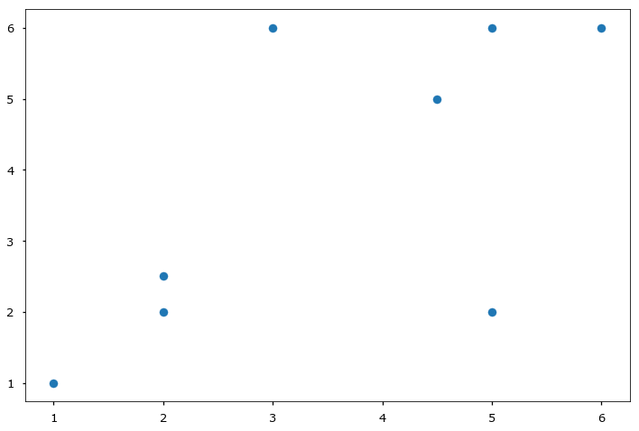

```python
plt.scatter(X[:,0], X[:,1])
```

```python
# А теперь сделаем это с питоном
from scipy.cluster.hierarchy import dendrogram, linkage
from scipy.cluster.hierarchy import fcluster, cophenet
```

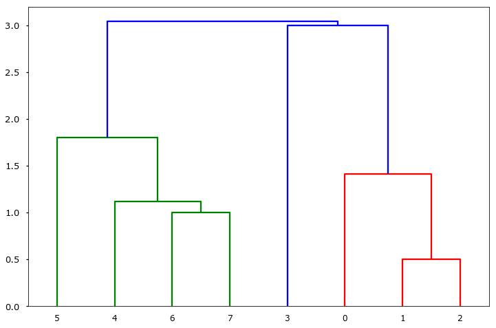

```python
Z = linkage(X, method='single', metric='euclidean')
dend = dendrogram(Z)
```

## Эвристика для оценки качества дендрограммы

- **Кофенетическое расстояние** между объектами $x_i$ и $x_j$ - высота дерева, при котором эти объекты объединились.

[figure not shown]

### Кофенетическая корреляция

- Кофенетическая корреляция — коэффициент корреляции между массивами попарных расстояний и попарных кофенетических расстояний.

$$ \text{cophCorr} = \frac{\sum\limits_{i < j}(d(x_i, x_j) - \bar{d})(coph(x_i, x_j) - \bar{coph})}{\sqrt{\sum\limits_{i < j}(d(x_i, x_j) - \bar{d})^2 \cdot \sum\limits_{i < j}(coph(x_i, x_j) - \bar{coph})^2}} $$

При "удачно" построенном дереве эти ряды должны сильно коррелировать.

```python
interact(coph_demo, k=IntSlider(min=2, max=10, step=1, value=2),
         link=['complete', 'single', 'average', 'centroid'],
         metric=['euclidean', 'cityblock'])
```

```
<function __main__.coph_demo(link='single', metric='euclidean', k=2)>
```

## Итог

#### Преимущества

- Разнообразие критериев
- Любые K из коробки
- Наглядность с дендрограммой

#### Недостатки

- Требует много ресурсов

# Алгоритмы, основанные на плотности

## DBSCAN

## Хотелось бы...

- Получить кластеры высокой плотности, разделеные участками низкой плотности

[figure not shown]

## Геоданные

## Основная идея

- Для каждой точки кластера её окрестность заданного радиуса $\epsilon$ должна содержать не менее некоторого числа точек `min_pts`.
- C такой точки можно начать расширение "плотного" кластера

#### Типы объектов

- Объект $x_i$ называется **сore-объектом**, если $N_\epsilon(x_i) \geq \texttt{min_pts}$
- Объект $x_i$ называется **граничным объектом**, если $N_\epsilon(x_i) < \texttt{min_pts}$, но $\exists x_j : d(x_i, x_j) \leq \epsilon$ и $x_j$ - core-объект
- Объект $x_i$ называется **шумовым**, если он не является ни граничным ни core объектом

[figure not shown]

## Demo

[Тык](https://www.naftaliharris.com/blog/visualizing-dbscan-clustering/)

```python
interact(dbscan_demo, eps=FloatSlider(min=0.1, max=10, step=0.05, value=1), min_pts=IntSlider(min=2, max=15, step=1, value=5))
```

```
<function __main__.dbscan_demo(eps=1, min_pts=5)>
```

## Итог

#### Преимущества

- Не требует $K$
- Кластеры произвольной формы
- Учитывает выбросы

#### Недостатки

- Не работает при различных плотностях кластеров

# Cluster Validity and Quality Measures

### Оценка качества кластеризации при известном groud truth

#### Доля правильно кластеризованных вешин

Пусть $\hat{\pi}$ - это полученное разбиение на кластеры, а $\pi^*$ - ground truth. Тогда доля правильно угаданных меток рассчитывается как

$$ Acc(\hat{\pi}, \pi^*) = \frac{\text{# of correctly clustered obs}}{N} \text{,}$$

где объект считается правильно кластеризован, если **хотя бы половина** объектов из того же кластера в $\hat{\pi}$ относится к некоторому кластеру в $\pi^*$

#### Adjusted Rand Index

$$ \text{Rand}(\hat{\pi},\pi^*) = \frac{a + d}{a + b + c + d} \text{,}$$

где

- $a$ - количество пар объектов, находящихся в одинаковых кластерах в $\hat{\pi}$ и $\pi^*$,
- $b$ ($c$) - количество пар объектов в одном и том же кластере в $\hat{\pi}$ ($\pi^*$), но в разных в $\pi^*$ ($\hat{\pi}$)
- $d$ - количество пар объектов в разных кластерах в $\hat{\pi}$ и $\pi^*$

#### Adjusted Rand Index

$$ \text{Rand}(\hat{\pi},\pi^*) = \frac{tp + tn}{tp + fp + fn + tn} \text{,}$$

где

- $tp$ - количество пар объектов, находящихся в одинаковых кластерах в $\hat{\pi}$ и $\pi^*$,
- $fp$ ($fn$) - количество пар объектов в одном и том же кластере в $\hat{\pi}$ ($\pi^*$), но в разных в $\pi^*$ ($\hat{\pi}$)
- $tn$ - количество пар объектов в разных кластерах в $\hat{\pi}$ и $\pi^*$

Adjusted Rand Index - корректировка Rand index:

$$\text{ARI}(\hat{\pi},\pi^*) = \frac{\text{Rand}(\hat{\pi},\pi^*) - \text{Expected}}{\text{Max} - \text{Expected}}$$

Так же есть **[Normalized Mutual Information](http://en.wikipedia.org/wiki/Mutual_information)**, но результаты этой метрики схожи с ARI

## Precision, Recall, F-measure

- $\text{Precision}(\hat{\pi},\pi^*) = \frac{tp}{tp+fn}$
- $\text{Recall}(\hat{\pi},\pi^*) = \frac{tp}{tp+fp}$
- $\text{F-measure}(\hat{\pi},\pi^*) = \frac{2\cdot Precision \cdot Recall}{Precision \cdot Recall}$

## Меры валидности кластеров

- Измеряют полученое разбиения по отношению к качествам хорошей кластеризации
  - Компактность объектов внутри кластера
  - Разделимость кластеров друг от друга

### Критерий Silhouette

Пусть дана кластеризация в $K$ кластеров, и объект $i$ попал в $C_k$

- $a(i)$ -- среднее расстояние от $i$ объекта до объектов из $C_k$
- $b(i) = min_{j \neq k} b_j(i)$, где $b_j(i)$ -- среднее расстояние от $i$ объекта до объектов из $C_j$ $$ silhouette(i) = \frac{b(i) - a(i)}{\max(a(i), b(i))} $$ Средний silhouette для всех точек из $\mathbf{X}$ является критерием качества кластеризации.

[figure not shown]

# Литература

- [Mohammed J. Zaki, Ch3](https://www.amazon.com/Data-Mining-Analysis-Fundamental-Algorithms/dp/0521766338)
- [Jure Leskovec, Anand Rajaraman, Jeffrey D. Ullman, Ch7](http://www.mmds.org/)
- [Andrew R. Webb, Keith D. Copsey, Ch11](http://eu.wiley.com/WileyCDA/WileyTitle/productCd-0470682272.html)